# 行政資訊管理期中報告

黃禹蜻、張昕穎、陳柔安

2019/4/23

*Due：Apr. 26, 2019*

**組員：** 第12組  
政治公行二B06302309黃禹蜻  
政治公行二B06302340張昕穎  
政治公行二B06302345陳柔安

### **研究問題：職業差異與投入休閒與教育金額之關係**

分析各家戶經濟戶長職業與該家戶之所得總額，並比較其與該家戶教育、休閒文化支出額度的關係。

### **研究動機：**

在求學過程中，我們時常看到有能力投入更多教育資源的家庭多為特定的職業類別，而且多半都是家戶所得較高的家庭。因此我們不禁懷疑教育是否真的能夠促進階級流動，抑或者反而更深化了階級複製的情形？

尤其近年來 *所得差異愈來愈大*，早已成為學術圈與社會各界關心的問題，過去臺大經濟系駱明慶教授曾發布一篇《誰是臺大學生－性別、省籍與城鄉差異》的論文，論文中指出考入臺大的雙北學生佔所有學生之50%，顯示城鄉資源與投入教育多寡差異現象；同樣地，《報導者The Reporter》網站在去年一篇《【數字說話】教育能翻轉人生嗎——高教的反向重分配現象》文章製作一項分析測試，探討家戶所得與進入臺大的機率比例。 **職業所得差距是否真的會影響家庭投入教育的支出？** 我們假設 **越高所得的職業家庭在教育支出的投入越多** 因此，我們希望藉由 *分析收支*，探討此項假設。再者，由於教育與文化、休閒類型同樣算是家庭之額外投資支出，我們也比較了 *職業在休閒與文化支出*的多寡。 此外，身處一個「出路很廣、未來職業不設限」的政治系的我們，也想藉由比較各職業類別的所得總額，以作為我們畢業後就業選擇的參考方向，是否要依循傳統腳步、追求穩定生活，考取公職，或是以個人興趣發展，從事其他不同種類的行業？

### **研究方法與分析：**

由於過去比較範圍多以全臺灣為主，較少有人分析人們所認為「豐饒富庶」的臺北市，因此我們以臺北市單一城市為例，由臺北市家庭收支資料庫查詢系統所提供的 *106年臺北市家戶收支資料*進行比較分析，將各職業別的家庭收入總額由高到低排序。 在文化與休閒及教育支出的研究部分，由於查詢系統提供的資料只有數字無法看出消費傾向，我們僅將之做成長條圖比較各職業差異。  
分析報告中的圖表藉由老師上課所教的R Studio程式進行，並根據統計網站之數據與組員的合作、同儕的指導完成。 為使圖表呈現更加簡練，我們以 **英文代號**（a, b,…, i）作為職業類別之代稱：  
a：民意代表、主管及經理人員  
b：專業人員  
c：技術員及助理專業人員  
d：農、林、漁、牧業生產人員  
e：技藝有關工作人員  
f：事務支援人員  
g：服務及銷售工作人員  
h：機械設備操作及組裝人員  
i：基層技術工及勞力工

### **分析結果：**

**各行業之所得收入總計比較**  
語法：

```r
getwd()
```

```
## [1] "C:/Users/Jouan/Desktop/台大/行資管/其中們/新增資料夾/期中報告/file"
```

```r
setwd("C:/Users/Jouan/Desktop/台大/行資管/其中們/新增資料夾/期中報告/file")
dir()
```

```
## [1] "106t.csv"        "106年.csv"       "行資管報告.html" "行資管報告.Rmd"
## [5] "報告.R"          "期中報告.Rproj"
```

```r
data1<-read.csv("106t.csv")
```

```r
library(ggplot2)
head(data1)
```

```
##          X total.income leisure education
## 1  average      1648122   88190     36106
## 2        a      2741928  168814     76163
## 3        b      2159371  121407     57355
## 4        c      1838326  100374     45448
## 5        d      1820695   63889     44292
## 6        e      1524474   69521     32472
```

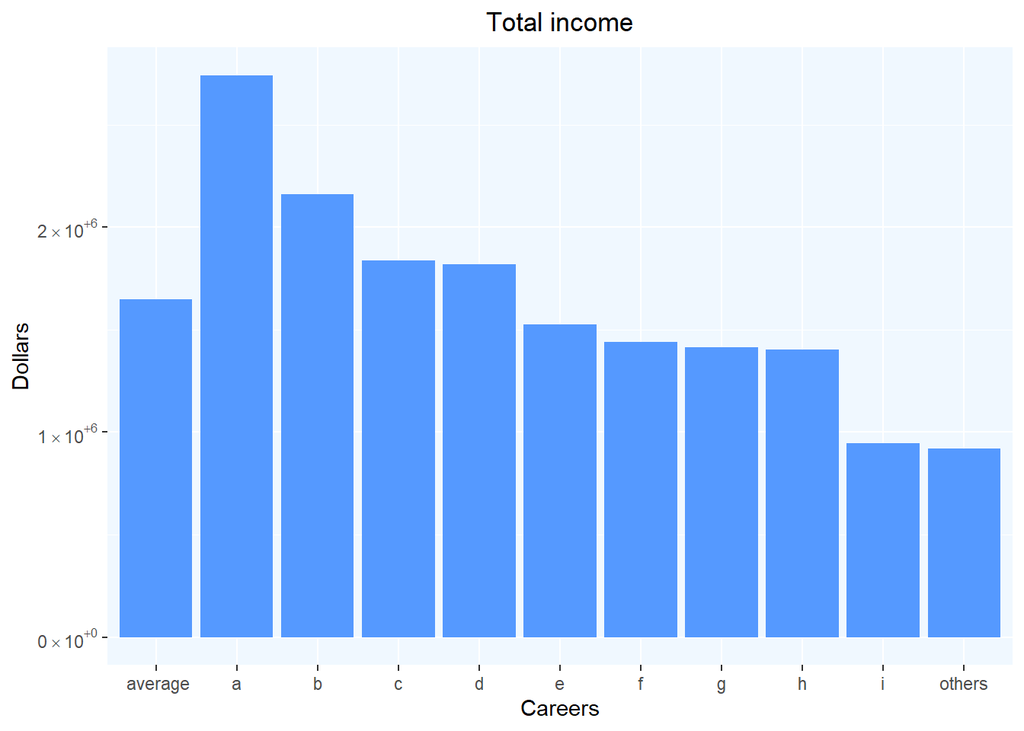

```r
fancy_scientific <- function(l) {
  # turn in to character string in scientific notation
  l <- format(l, scientific = TRUE)
  # quote the part before the exponent to keep all the digits
  l <- gsub("^(.*)e", "'\\1'e", l)
  # turn the 'e+' into plotmath format
  l <- gsub("e", "%*%10^", l)
  # return this as an expression
  parse(text=l)
}
library(ggplot2)
careers<-c("average","a","b","c","d","e","f","g","h","i","others")
under<-ggplot(data=data1,
              aes(x=data1$X,y=data1$total.income))+
  scale_y_continuous(labels=fancy_scientific)
under+
  geom_bar(stat="identity",fill="#5599FF")+
  ggtitle("Total income")+
  xlab("Careers")+ylab("Dollars")+
  theme(panel.background=element_rect(fill="#F0F8FF",size=2,linetype="solid"),plot.title=element_text(hjust = 0.5))
```

圖（一）

從中我們可以看出 **a、民意代表、主管及經理人員**之所得收入遠高於次高之職業 **b、專業人員**，甚至高於 **i、基層技術工及勞工**近 *三倍差距*。  
至此，我們是否能證明假設「越高所得的職業家庭在教育支出的投入越多」為正確？在此假設下， **所得收入與教育支出關聯成高度正相關**，因此，若我們能證明不同職業家庭在教育支出的花費呈現與此圖表相似，則假設便成立。

以下是我們利用R Stusio程式所分析出的職業家庭在教育支出上的金額圖形：  
語法：

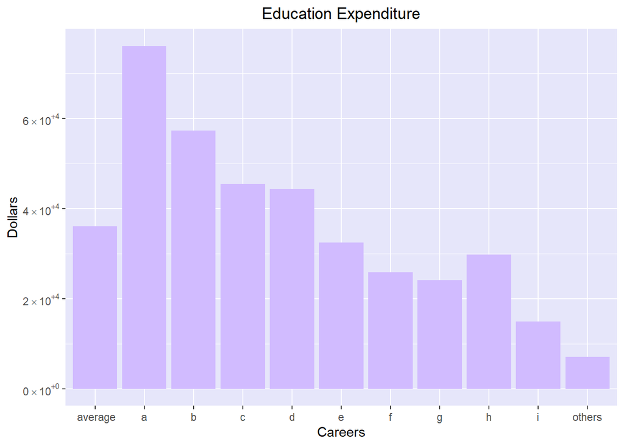

```r
under1<-ggplot(data=data1,
              aes(x=data1$X,y=data1$education))+
  scale_y_continuous(labels=fancy_scientific)
under1+
  geom_bar(stat="identity",fill="#D1BBFF")+
  ggtitle("Education Expenditure")+
  xlab("Careers")+ylab("Dollars")+
  theme(panel.background=element_rect(fill="#E6E6FA",size=2,linetype="solid"),plot.title=element_text(hjust = 0.5))
```

圖（二）

參照圖（一）與此圖可以發現， **所得越高的家戶在教育支出上的投入會越多**，而這也意味著 **所得越高的家庭的子代得以享有更豐富的教育資源**。 論文《論家戶所得與資產對子女教育之影響－以1993-1995出生世代及其稅務資料為例》中也發現，「越是熱門、學生競相報考申請的校系，家庭背景較好的學生就讀的機率越大」，也就是 *原生家庭背景與父母所得和子代的教育程度是呈高度相關的*，而這些發現與我們以往的認知背道而馳，或許 **教育並未能有效的促進階級流動，反而是深化了階級複製的情形**。

同樣，與教育支出相照的有不同行業在休閒與文化支出的金額差異：  
語法：

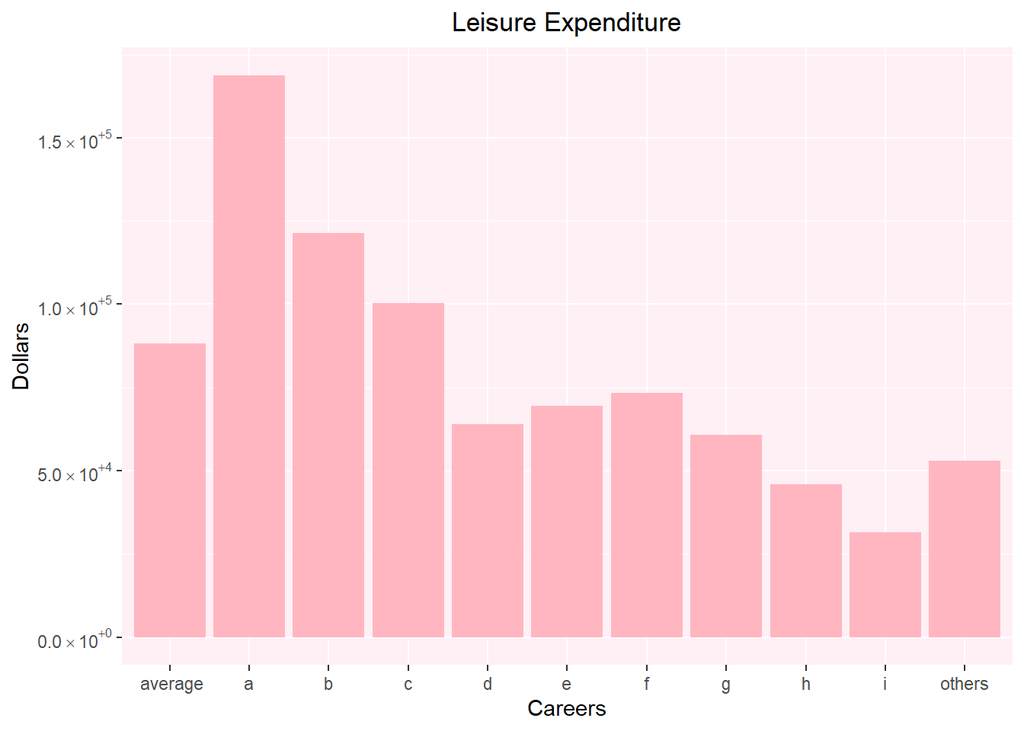

```r
under2<-ggplot(data=data1,
               aes(x=data1$X,y=data1$leisure))+
  scale_y_continuous(labels=fancy_scientific)
under2+
  geom_bar(stat="identity",fill="#FFB6C1")+
  ggtitle("Leisure Expenditure")+
  xlab("Careers")+ylab("Dollars")+
  theme(panel.background=element_rect(fill="#FFF0F5",size=2,linetype="solid"),plot.title=element_text(hjust = 0.5))
```

圖（三）

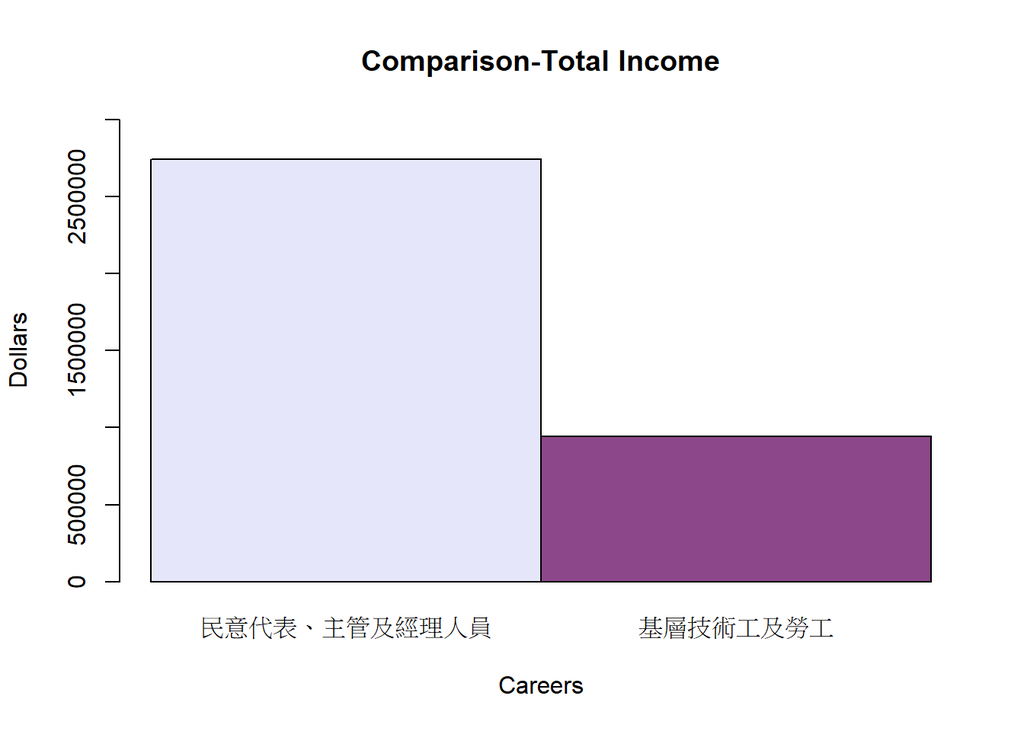

```r
a<-c(2741928)
i<-c(944126)
names=c("民意代表、主管及經理人員","基層技術工及勞工")
dollars<-matrix(c(a,i),2,1)
colors<-c("lavender","orchid4")
barplot(dollars,names.arg=names,main="Comparison-Total Income",col=colors,xlab="Careers",ylab="Dollars",cex.names=1,ylim=c(0,3000000),beside=TRUE)
```

圖（四）

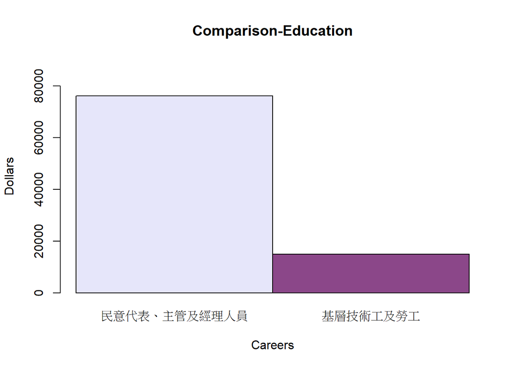

```r
a1<-c(76163)
i1<-c(14875)
names=c("民意代表、主管及經理人員","基層技術工及勞工")
dollars1<-matrix(c(a1,i1),2,1)
colors<-c("lavender","orchid4")
barplot(dollars1,names.arg=names,main="Comparison-Education",col=colors,xlab="Careers",ylab="Dollars",cex.names=1,ylim=c(0,90000),beside=TRUE)
```

圖（五）

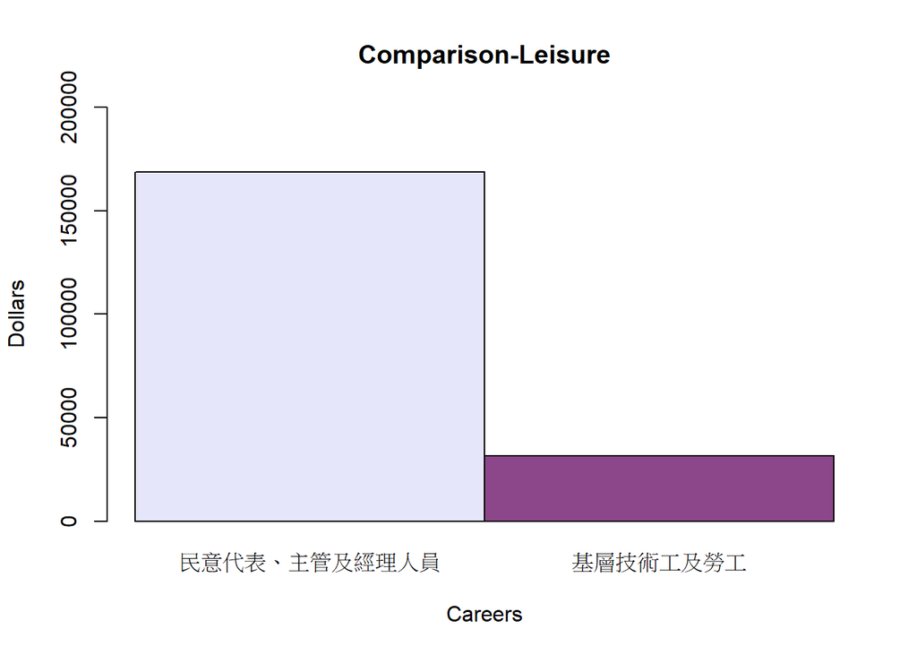

```r
a2<-c(168814)
i2<-c(31400)
names=c("民意代表、主管及經理人員","基層技術工及勞工")
dollars2<-matrix(c(a2,i2),2,1)
colors<-c("lavender","orchid4")
barplot(dollars2,names.arg=names,main="Comparison-Leisure",col=colors,xlab="Careers",ylab="Dollars",cex.names=1,ylim=c(0,200000),beside=TRUE)
```

圖（六）

三張圖（圖四、五、六）使用barplot語法，由於三項比較（所得、教育與休閒支出）間的y軸數據（金額）差異過大，使用ggplot上有執行之困難，因此我們採用的是較為明顯與清楚的barplot語法。  
以上三張圖可以明顯看出兩個職業間收入與支出的差異，令我們感到訝異的是，兩者間的差距超乎想像的大。

### **結果討論：**

根據本次分析的結果，我們回到假設 **越高所得的職業家庭在教育支出的投入越多**，在以上圖表可得出 **收入多寡對支出成高度正相關**，代表我們的 *假設成立*；而在此分析中，我們可以得知，所得較高的家庭傾向於投入更多的支出在教育、休閒方面，使得家中子代能獲得更充裕豐富的教學資源與環境，更有能力供子女赴海外遊學、參加夏(冬令營)等各種活動，有助於其教育成就、學位的取得，反之，經濟弱勢家庭的子代所能獲得的資源是相對非常不足的。這種不對等的資源分配，或許便是階級複製最根深柢固的原因。

我們同樣也推論 **獲得高額教育與休閒經費**的家庭學童，比較獲得低額經費的家庭學童，在高等教育、語言水平、課外才藝、閱歷及見識，甚至未來成就上，獲得高額教育經費學童的起跑線遠在其他學童之前。尤其在臺灣現行教育制度中，被戲稱為「多錢入學」的評分方式，更加拉大了教育與休閒文化資源對不同收入階層家庭中學童的影響程度。

而本次分析僅分析臺北市單一城市職業差異，或許推到全臺灣，此差異可能因高所得職業所獲得所得不如臺北市內部而減低，低所得職業所獲得所得也可能更加低落，兩方交互比較下在教育與休閒支出差異多寡難以推估；再者，本次我們也僅分析職業對教育支出的關聯性，除職業外，家庭教育程度、父母對子女期望、個人特質、自我期望等因素同樣會影響家庭在教育支出上的比例與金額多寡，若需持續分析則參與之影響因子過多，所需建模程式與參考數據資料更為複雜，難以短時間內比較得出。

就臺北市而言，我們證實了這個關聯性，也認為現今社會上所談論的 *階級複製*問題並沒有解決，它仍舊存在，並深深影響我們的生活。  
因此，我們希望政府能領先做起，評估現況、與學者及民間人士多方討論，並著手制定相關政策，（例如：保障基層勞工與技術人員薪資水平、進行重分配政策以改善貧富差距）以減緩職業間薪資差異對家戶所得差距與投入教育資源的影響，此外更應確保經濟弱勢家庭的子女能獲得同等的升學、獲教育機會，或許能透過開設獎助學金、由政府分配較多資源給弱勢家庭稍微改善，才能避免因貧富差異減損了教育的公平性，以及更長遠的－－後代階級流動提升的可能。

### **資料來源：**

**台北市家庭收支資料庫查詢系統**  
http://210.69.61.217/pxweb2007-tp/dialog/statfile9_FI.asp  
**《The News Lens關鍵新聞網》〈台大怎麼上：誰是台大學生2.0〉**  
https://www.thenewslens.com/article/85532  
**《論家戶所得與資產對子女教育之影響－以1993-1995出生世代及其稅務資料為例》－沈暉智、林明仁（106）**  
**我國休閒文化支出 續攀新高-中時電子報**  
https://www.chinatimes.com/newspapers/20160413000066-260202?chdtv